# Visualization 1

# More plot options

Add color to scatterplot by using name as the aesthetic.

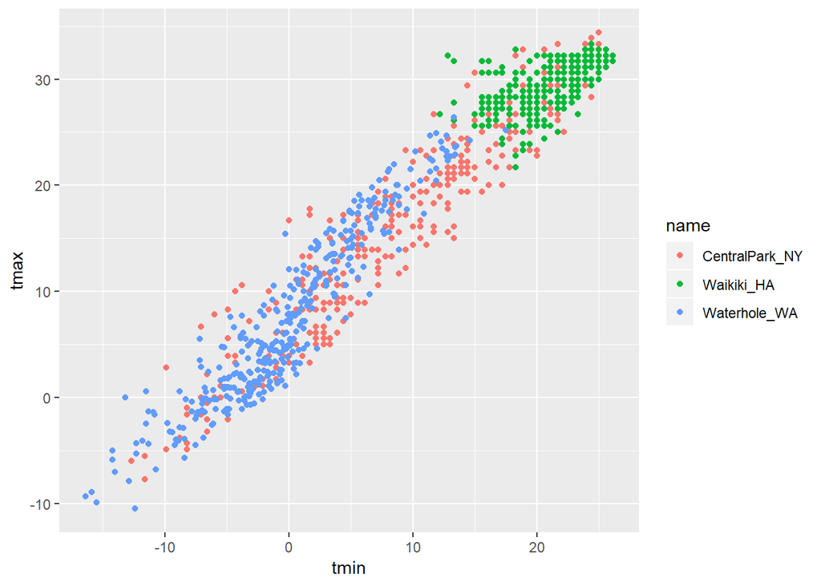

```r
ggplot(weather_df, aes(x = tmin, y = tmax)) +
  geom_point(aes(color = name))
```

Add another geom.

geom_smooth() plots a smooth line through your data. Include option to not include the SE bands around the line for this case.

Notice that the geom_smooth line is a single color because the color mapping is only within geom_point.

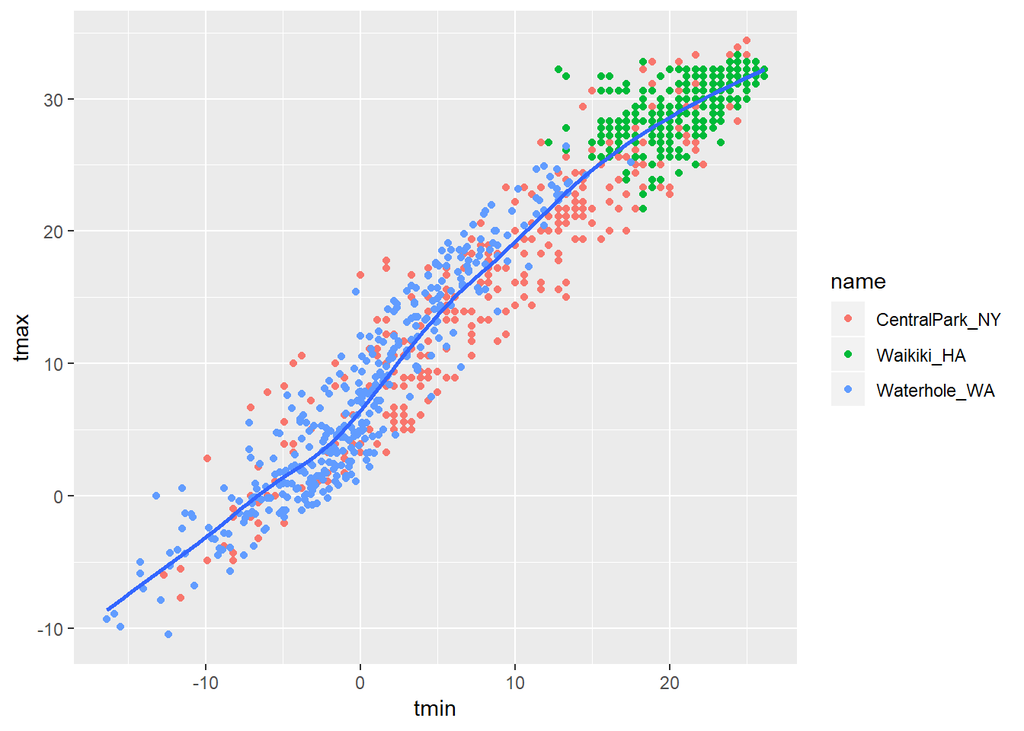

```r
ggplot(weather_df, aes(x = tmin, y = tmax)) +
  geom_point(aes(color = name)) +
  geom_smooth(se = FALSE)
```

Adjust alpha parameter in geom_point to adjust transperancy of points

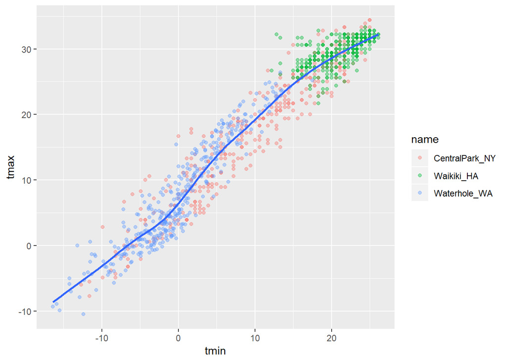

```r
ggplot(weather_df, aes(x = tmin, y = tmax)) +
  geom_point(aes(color = name), alpha = 0.4) +
  geom_smooth(se = FALSE)
```

When the aesthetics are moved to ggplot, all geoms are affected.

geom_smooth graphs multiple lines with colors matching the points because the aesthetics differntiates the data into 3 clusters based on the locations (Central Park, HA, WA)

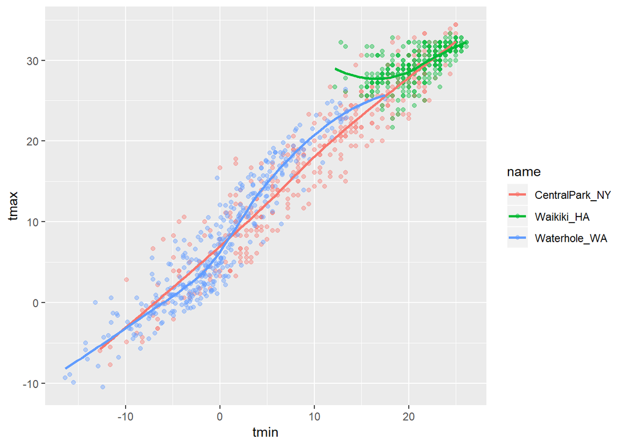

```r
ggplot(weather_df, aes(x = tmin, y = tmax, color = name)) +
  geom_point(alpha = 0.4) +
  geom_smooth(se = FALSE)
```

# Facetting

Create separate graphs for each value of name

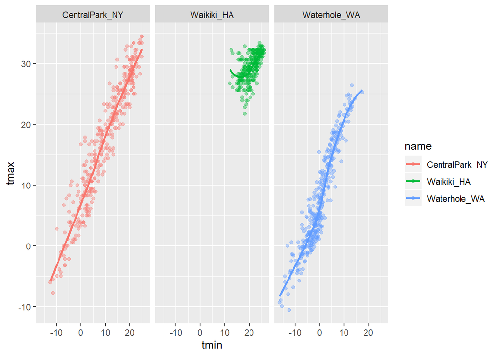

```r
ggplot(weather_df, aes(x = tmin, y = tmax, color = name)) +
  geom_point(alpha = 0.4) +
  geom_smooth(se = FALSE) +
  facet_grid(~ name)
```

# More interesting plots

Look at max temperature over the course of a year

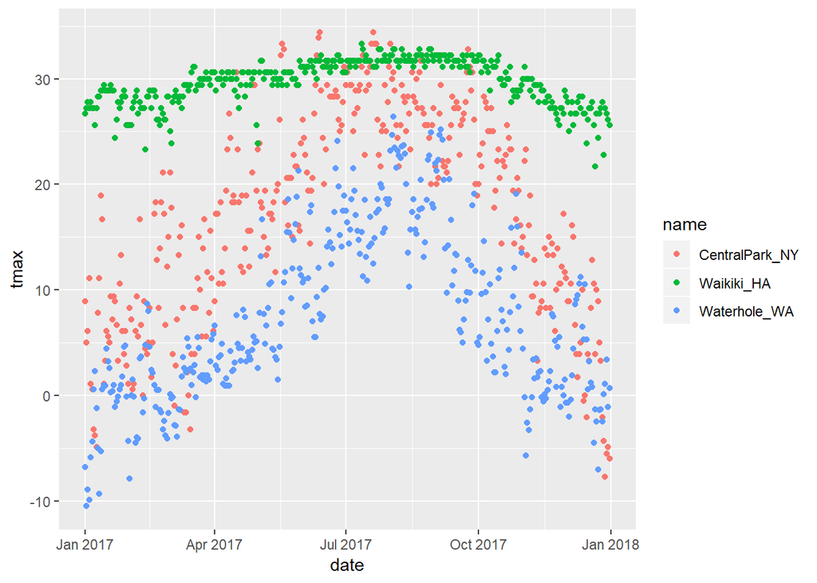

```r
ggplot(weather_df, aes(x = date, y = tmax, color = name)) +
  geom_point()
```

Instead of points, we can graph lines

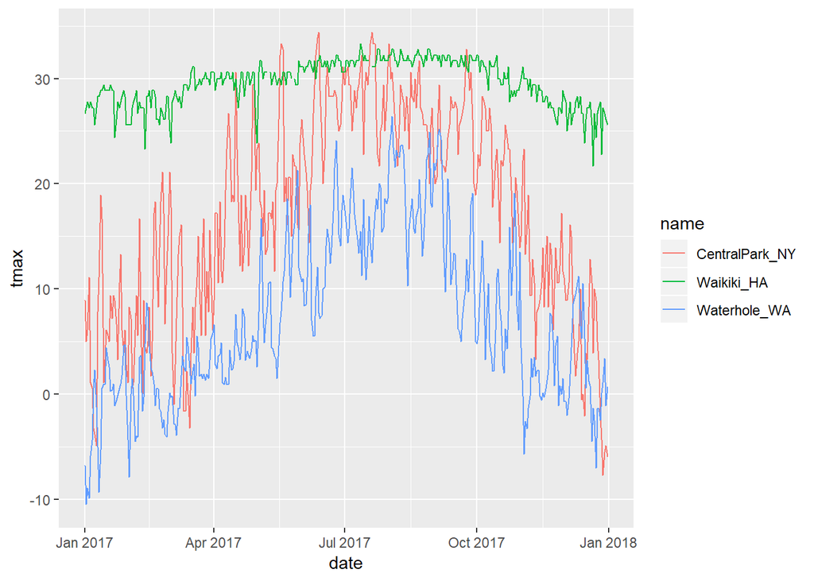

```r
ggplot(weather_df, aes(x = date, y = tmax, color = name)) +
  geom_line()
```

Add another aes option to make points small/large depending on value of precipitation (prcp)

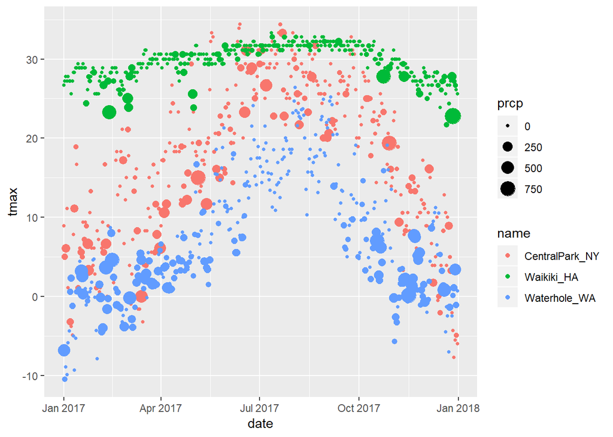

```r
ggplot(weather_df, aes(x = date, y = tmax, color = name, size = prcp)) +
  geom_point()
```

More smoothing options

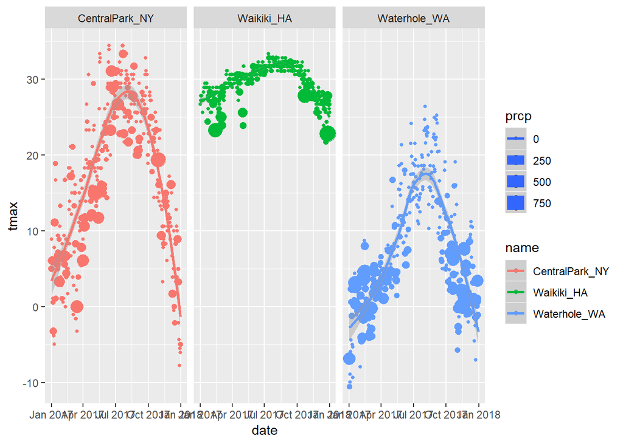

```r
ggplot(weather_df, aes(x = date, y = tmax, color = name, size = prcp)) +
  geom_point() +
  geom_smooth() +
  facet_grid(~ name)
```

# Univariate plots

## Histograms

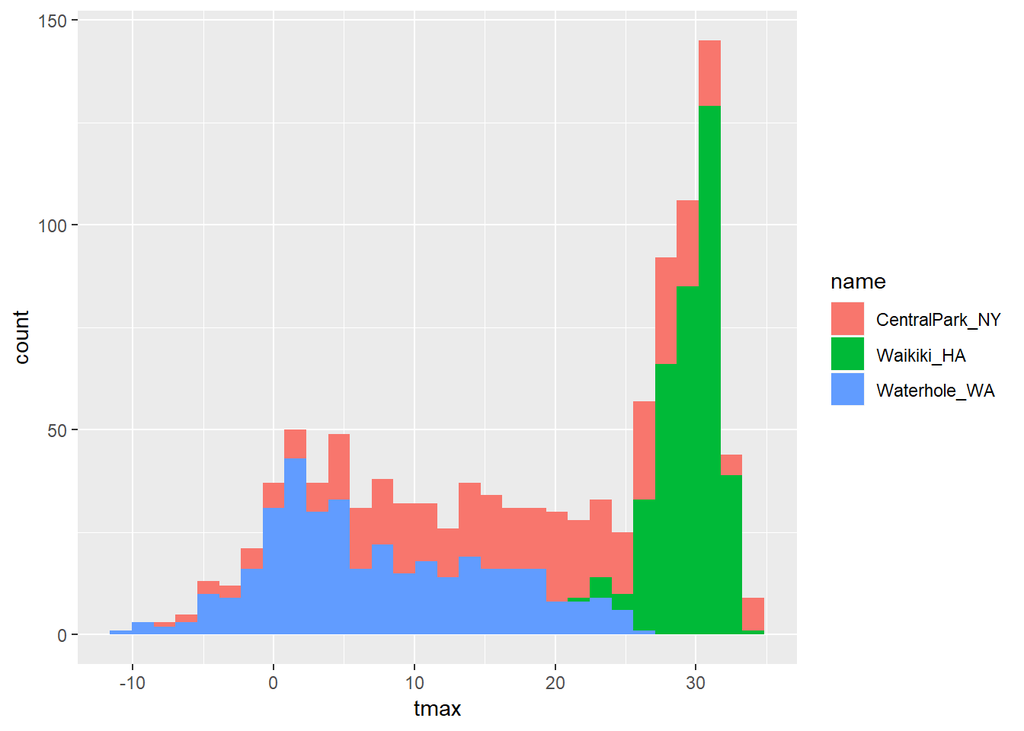

```r
ggplot(weather_df, aes(x = tmax, fill = name)) +
  geom_histogram()
```

## Density plot

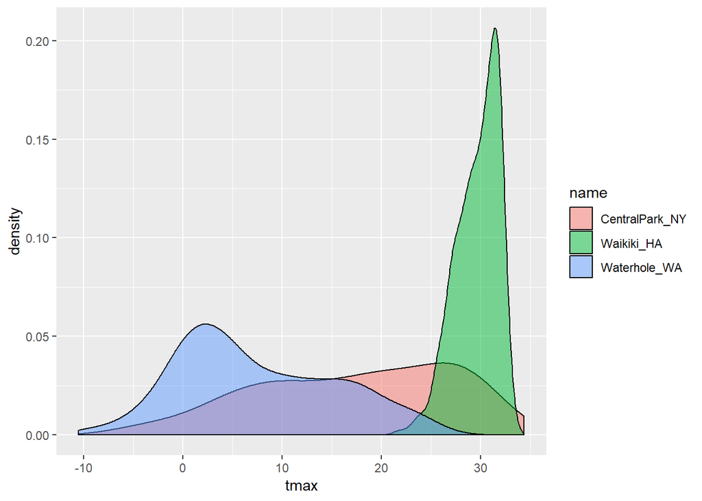

```r
ggplot(weather_df, aes(x = tmax, fill = name)) +
  geom_density(alpha = 0.5)
```

## Box plot

Box plot aes is y-axis for the value, not x-axis like histogram and density plots. x-axis aes will help with separate box plots

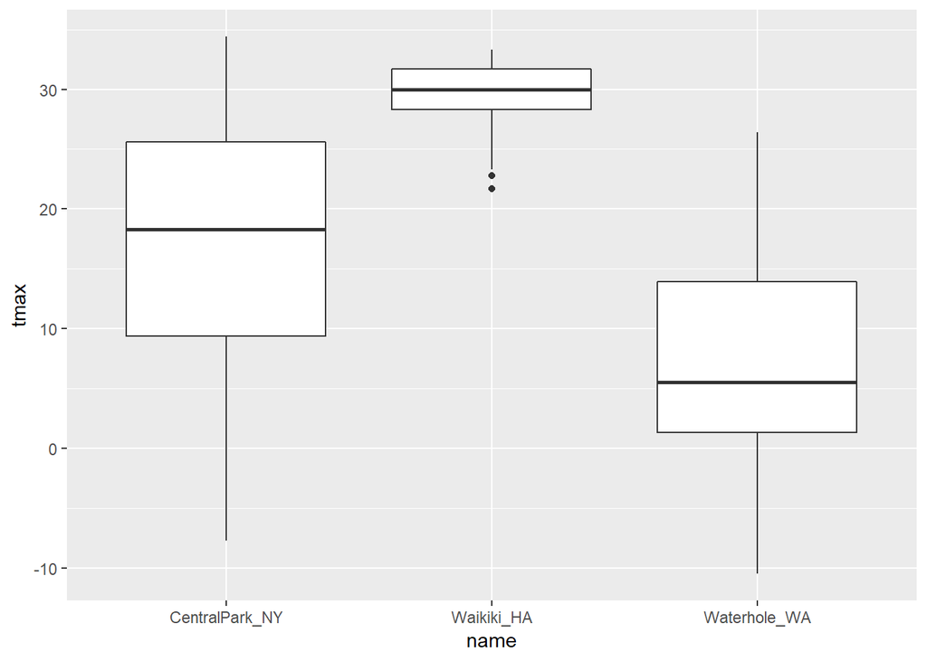

```r
ggplot(weather_df, aes(x = name, y = tmax)) +
  geom_boxplot()
```

## Violin plot

Convey distribution info like box and density plot combined

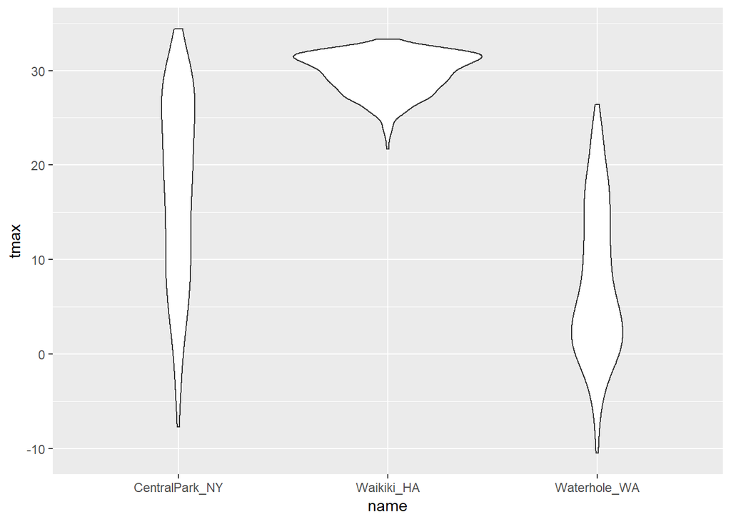

```r
ggplot(weather_df, aes(x = name, y = tmax)) +
  geom_violin()
```

## Putting ggridges to work to make ridge plots

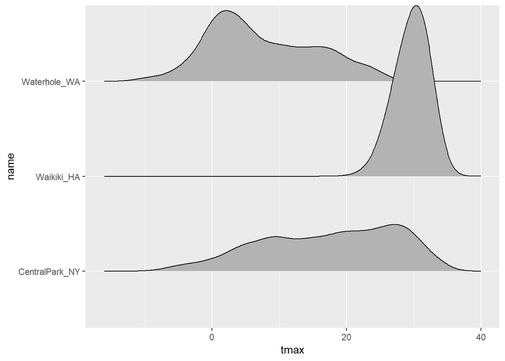

```r
ggplot(weather_df, aes(x = tmax, y = name)) +
  geom_density_ridges()
```

# Saving or embedding ggplots

Save as pdf

```r
ridge_plot <- ggplot(weather_df, aes(x = tmax, y = name)) +
  geom_density_ridges()
ggsave('ridge_plot.pdf', ridge_plot, width = 8, height = 5)
```

Options like this give you control for sizing/aspect ratio stuff for saved plots

```r
knitr::opts_chunk$set(
  fig.width = 6,
  fig.asp = .6,
  out.width = "90%"
)
```

# Last example

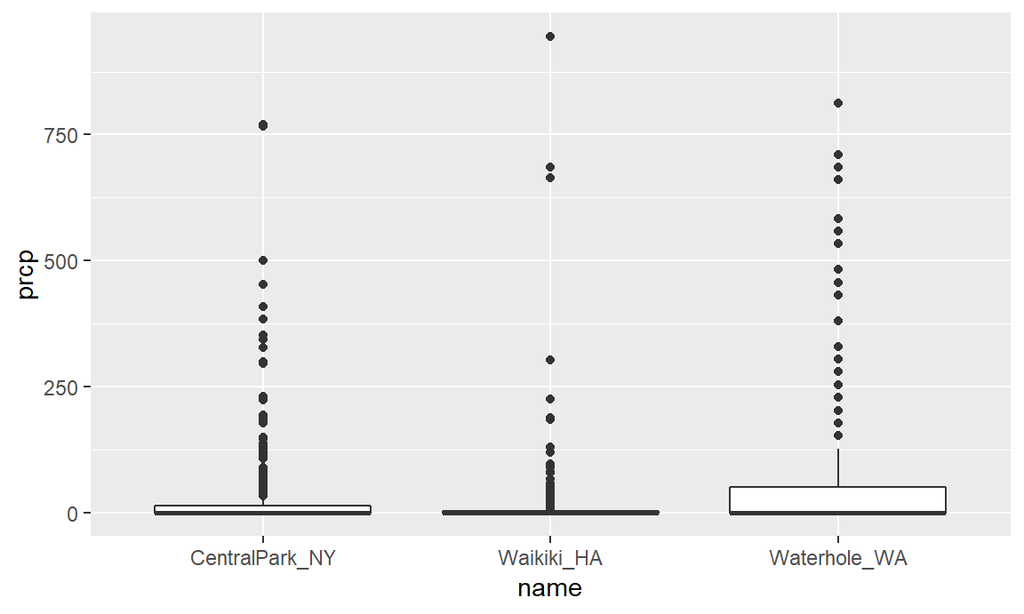

```r
ggplot(weather_df, aes(y = prcp, x = name)) + geom_boxplot()
```